# GWAS

# Import and manage data

```r
# Import packages
library(snpStats)
# Import the files
ob.plink <-
  read.plink(bed = "obesity.bed", bim = "obesity.bim", fam = "obesity.fam")
```

```r
# Extract the genotype, annotation, family, and phenotype data
geno <- ob.plink$genotypes
annotation <- ob.plink$map
family <- ob.plink$fam
pheno <- read.delim("obesity.txt")
```

```r
# Rename the rows of “pheno” with the “id” variable
rownames(pheno) <- pheno$id
```

```r
# Select the common individuals between the files
ids <- intersect(rownames(pheno), rownames(geno))
geno <- geno[ids,]
pheno <- pheno[ids,]
family <- family[ids,]
```

# Quality control (QC)

it involves:

- QC of SNPs
- QC of individuals
- QC of Population ancestry

### QC of SNPs

Measures to perform QC:

- Remove SNPs with a high rate of missing
- Remove rare SNPs (e.g. having low minor allele frequency - MAF)
- Remove SNPs that do not pass the HWE test

```r
# Import packages
library(snpStats)
```

```r
# Filter SNPs with a call rate > 95%, MAF of > 5% and z.HWE < 3.3 (p=0.001) in controls
controls <- pheno$obese == 0 & !is.na(pheno$obese)
geno.controls <- geno[controls, ]
info.snps <- col.summary(geno)
info.controls <- col.summary(geno.controls)
use <-
  info.snps$Call.rate > 0.95 &
  info.snps$MAF > 0.05 & abs(info.controls$z.HWE < 3.3)
mask.snps <- use & !is.na(use)
geno.qc.snps <- geno[, mask.snps]
annotation <- annotation[mask.snps,]
```

```r
# Number of SNPs removed for bad call rate
sum(info.snps$Call.rate < 0.95)
```

```
## [1] 869
```

```r
# Number of SNPs removed for low MAF
sum(info.snps$MAF < 0.05, na.rm = TRUE)
```

```
## [1] 10553
```

```r
# Number of SNPs that do not pass HWE test
sum(abs(info.controls$z.HWE > 3.3), na.rm = TRUE)
```

```
## [1] 56
```

```r
# The total number of SNPs do not pass QC
sum(!mask.snps)
```

```
## [1] 11342
```

### QC of individuals

Measures to perform QC:

- The identification of individuals with discordant reported and genomic sex: Males have expected heterozygosity of chromosome X of 0 and females of 0.30.
- The identification of individuals with outlying missing genotype or heterozygosity rate.
- The identification of duplicated or related individuals.
- The identification of individuals of divergent ancestry from the sample.

```r
# Import packages
library(SNPRelate)
library(SNPassoc)
```

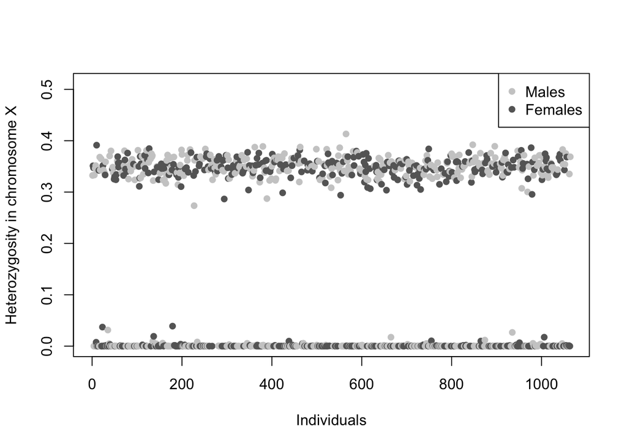

```r
# Identifying individuals with sex discrepancies
geno.X <-
  geno.qc.snps[, annotation$chromosome == "23" &
                 !is.na(annotation$chromosome)]
info.X <- row.summary(geno.X)
mycol <- ifelse(pheno$gender == "Male", "gray40", "gray80")
plot(
  info.X$Heterozygosity,
  col = mycol,
  pch = 16,
  xlab = "Individuals",
  ylab = "Heterozygosity in chromosome X"
)
legend("topright",
       c("Males", "Females"),
       col = mycol,
       pch = 16)
```

```r
sex.discrep <-
  (pheno$gender == "Male" &
     info.X$Heterozygosity > 0.2) |
  (pheno$gender == "Female" & info.X$Heterozygosity < 0.2)
```

```r
# Identifying individuals with outlying heterozygosity from the overall genomic heterozygosity rate
info.indv <- row.summary(geno.qc.snps)
MAF <- col.summary(geno.qc.snps)$MAF
callmatrix <- !is.na(geno.qc.snps)
hetExp <- callmatrix %*% (2 * MAF * (1 - MAF))
hetObs <-
  with(info.indv, Heterozygosity * (ncol(geno.qc.snps)) * Call.rate)
info.indv$hetF <- 1 - (hetObs / hetExp)
```

```r
# Identifying individuals whose relatedness is higher than expected
snpgdsBED2GDS("obesity.bed", "obesity.fam", "obesity.bim", out = "obGDS")
```

```
## Start file conversion from PLINK BED to SNP GDS ...
##     BED file: 'obesity.bed'
##         SNP-major mode (Sample X SNP), 55.1M
##     FAM file: 'obesity.fam'
##     BIM file: 'obesity.bim'
## Sun Jun 26 10:42:57 2022     (store sample id, snp id, position, and chromosome)
##     start writing: 2312 samples, 100000 SNPs ...
##
[..................................................]  0%, ETC: ---
[==================================================] 100%, completed, 3s
## Sun Jun 26 10:43:00 2022     Done.
## Optimize the access efficiency ...
## Clean up the fragments of GDS file:
##     open the file 'obGDS' (55.7M)
##     # of fragments: 39
##     save to 'obGDS.tmp'
##     rename 'obGDS.tmp' (55.7M, reduced: 252B)
##     # of fragments: 18
```

```r
genofile <- snpgdsOpen("obGDS")
snps.qc <- colnames(geno.qc.snps)
snp.prune <-
  snpgdsLDpruning(genofile, ld.threshold = 0.2, snp.id = snps.qc)
```

```
## SNP pruning based on LD:
## Excluding 13,476 SNPs (non-autosomes or non-selection)
## Excluding 0 SNP (monomorphic: TRUE, MAF: NaN, missing rate: NaN)
##     # of samples: 2,312
##     # of SNPs: 86,524
##     using 1 thread
##     sliding window: 500,000 basepairs, Inf SNPs
##     |LD| threshold: 0.2
##     method: composite
## Chromosome 1: 31.60%, 2,440/7,721
## Chromosome 2: 29.99%, 2,414/8,050
## Chromosome 3: 30.92%, 2,064/6,676
## Chromosome 4: 31.01%, 1,838/5,927
## Chromosome 5: 30.94%, 1,879/6,074
## Chromosome 6: 28.06%, 1,894/6,750
## Chromosome 7: 31.03%, 1,662/5,356
## Chromosome 8: 28.75%, 1,602/5,572
## Chromosome 9: 31.37%, 1,480/4,718
## Chromosome 10: 30.92%, 1,605/5,191
## Chromosome 11: 31.14%, 1,486/4,772
## Chromosome 12: 31.80%, 1,544/4,855
## Chromosome 13: 31.14%, 1,134/3,642
## Chromosome 14: 32.81%, 1,066/3,249
## Chromosome 15: 31.70%, 970/3,060
## Chromosome 16: 35.05%, 1,042/2,973
## Chromosome 17: 36.42%, 991/2,721
## Chromosome 18: 34.08%, 1,004/2,946
## Chromosome 19: 40.56%, 690/1,701
## Chromosome 20: 35.62%, 858/2,409
## Chromosome 21: 34.90%, 489/1,401
## Chromosome 22: 34.36%, 548/1,595
## 30,700 markers are selected in total.
```

```r
snps.ibd <- unlist(snp.prune, use.names = FALSE)
ibd <-
  snpgdsIBDMoM(genofile,
               kinship = TRUE,
               snp.id = snps.ibd,
               num.thread = 1)
```

```
## IBD analysis (PLINK method of moment) on genotypes:
## Excluding 69,300 SNPs (non-autosomes or non-selection)
## Excluding 0 SNP (monomorphic: TRUE, MAF: NaN, missing rate: NaN)
##     # of samples: 2,312
##     # of SNPs: 30,700
##     using 1 thread
## PLINK IBD:    the sum of all selected genotypes (0,1,2) = 32805029
## Sun Jun 26 10:43:10 2022    (internal increment: 6656)
##
[..................................................]  0%, ETC: ---
[===========================================>......] 87%, ETC: 2s
[==================================================] 100%, completed, 18s
## Sun Jun 26 10:43:29 2022    Done.
```

```r
ibd.kin <- snpgdsIBDSelection(ibd)
ibd.kin.thres <- subset(ibd.kin, kinship > 0.1)
ids.rel <-  related(ibd.kin.thres)
```

```r
# Removing all above (individuals with more than 3-7% missing genotypes, with sex discrepancies, F absolute value > 1 and kinship coefficient > 0.1)
use <-
  info.indv$Call.rate > 0.95 &
  abs(info.indv$hetF) < 0.1 &
  !sex.discrep & !rownames(info.indv) %in% ids.rel
mask.indiv <- use & !is.na(use)
geno.qc <- geno.qc.snps[mask.indiv,]
pheno.qc <- pheno[mask.indiv,]
```

```r
# Number of individuals removed to bad call rate
sum(info.indv$Call.rate < 0.95)
```

```
## [1] 19
```

```r
# Number of individuals removed for heterozygosity problems
sum(abs(info.indv$hetF) > 0.1)
```

```
## [1] 9
```

```r
# Number of individuals removed for sex discrepancies
sum(sex.discrep)
```

```
## [1] 534
```

```r
# Number of individuals removed to be related with others
length(ids.rel)
```

```
## [1] 14
```

```r
# The total number of individuals that do not pass QC
sum(!mask.indiv)
```

```
## [1] 554
```

### QC of Population ancestry

Ancestral differences can be inferred with principal component analysis (PCA) on the genomic data. Individuals with outlying ancestry can be removed from the study while smaller differences in ancestry can be adjusted in the association models, including the first principal components as covariates.

```r
# Import packages
library(SNPRelate)
```

```r
# Compute PCA on genomic data
pca <-
  snpgdsPCA(
    genofile,
    sample.id = rownames(geno.qc),
    snp.id = snps.ibd,
    num.thread = 1
  )
```

```
## Principal Component Analysis (PCA) on genotypes:
## Excluding 69,300 SNPs (non-autosomes or non-selection)
## Excluding 0 SNP (monomorphic: TRUE, MAF: NaN, missing rate: NaN)
##     # of samples: 510
##     # of SNPs: 30,700
##     using 1 thread
##     # of principal components: 32
## PCA:    the sum of all selected genotypes (0,1,2) = 7236148
## CPU capabilities: Double-Precision SSE2
## Sun Jun 26 10:43:33 2022    (internal increment: 952)
##
[..................................................]  0%, ETC: ---
[==================================================] 100%, completed, 5s
## Sun Jun 26 10:43:38 2022    Begin (eigenvalues and eigenvectors)
## Sun Jun 26 10:43:38 2022    Done.
```

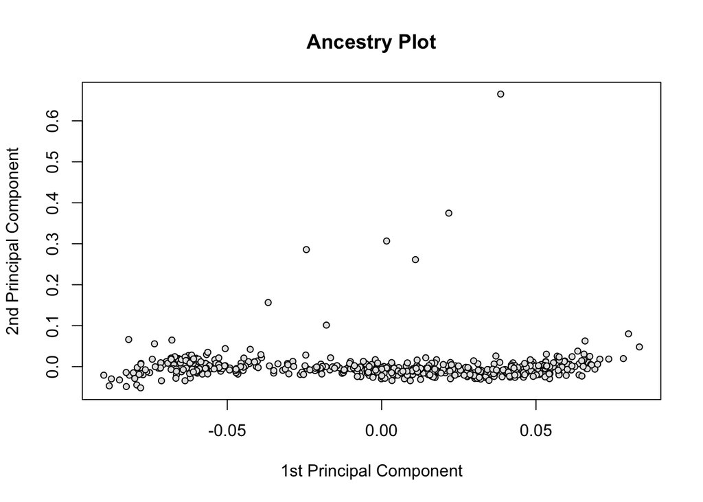

```r
# Obtain a PCA plot for the first two components
with(
  pca,
  plot(
    eigenvect[, 1],
    eigenvect[, 2],
    xlab = "1st Principal Component",
    ylab = "2nd Principal Component",
    main = "Ancestry Plot",
    pch = 21,
    bg = "gray90",
    cex = 0.8
  )
)
```

```r
# Add the first five principal components to the phenotypic information
pheno.qc <- data.frame(pheno.qc, pca$eigenvect[, 1:5])

# Close the GDS file
closefn.gds(genofile)
```

# GWAS analysis

It involves regressing each SNP separately on our trait of interest.

```r
# Import packages
library(snpStats)
```

```r
# Analysis for the additive (χ2(1.df)) and the codominant models (χ2(2.df))
res <- single.snp.tests(obese, data = pheno.qc, snp.data = geno.qc)
res[1:5, ]
```

```
##               N Chi.squared.1.df Chi.squared.2.df     P.1df     P.2df
## MitoT9699C  494       0.01484801               NA 0.9030159        NA
## MitoA11252G 481       0.15525272               NA 0.6935654        NA
## MitoA12309G 493       0.99339544               NA 0.3189139        NA
## MitoG15044A 491       1.24882939               NA 0.2637762        NA
## MitoG16130A 478       0.38483479        0.8911103 0.5350270 0.6404686
```

```r
# Analysis for a quantitative trait using the additive model
res.quant <-
  snp.rhs.tests(age ~ 1,
                data = pheno.qc,
                snp.data = geno.qc,
                family = "Gaussian")
head(res.quant)
```

```
##            Chi.squared Df   p.value
## MitoT9699C   0.2882815  1 0.5913239
```

### Adjusting for population stratification

The inflation of the associations due to undetected latent variables is assessed by quantile-quantile (Q-Q) plots where observed χ2 values are plotted against the expected ones. A Q-Q plot with top SNPs outside the confidence bands indicates that those SNPs are truly associated with the disease and, hence, do not follow the null hypothesis.

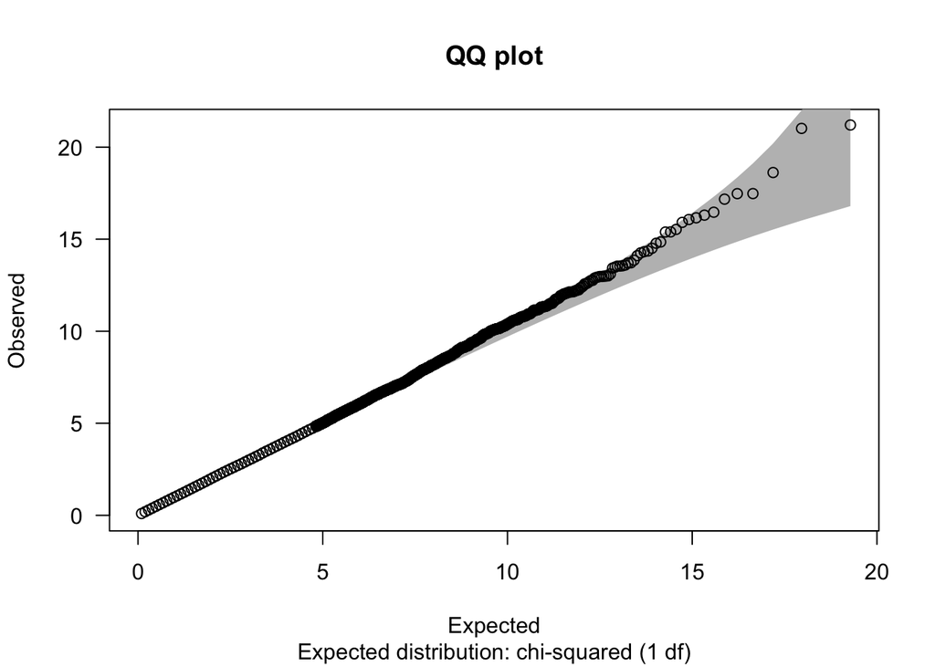

```
##            N      omitted       lambda
## 88658.000000     0.000000     1.008379
```

```r
# QQ-plot
chi2 <- chi.squared(res, df=1)
qq.chisq(chi2)
```

```r
# Adjust for population stratification using the PCs on genomic data to infer ancestral differences in the sample
res.adj <-
  snp.rhs.tests(obese ~ X1 + X2 + X3 + X4 + X5, data = pheno.qc, snp.data =
                  geno.qc)
head(res.adj)
```

```
##            Chi.squared Df   p.value
## MitoT9699C  0.00711969  1 0.9327557
```

```r
# Manhattan plot function
manhattanPlot <- function(x,
                          colors = c("grey", "skyblue"),
                          significantLine = 8,
                          snpsOfInterest = NULL,
                          ...) {
  don <- x %>%

    # Compute chromosome size
    group_by(CHR) %>%
    dplyr::summarise(chr_len = max(BP)) %>%

    # Calculate cumulative position of each chromosome
    mutate(tot = cumsum(as.numeric(chr_len)) - chr_len) %>%
    dplyr::select(-chr_len) %>%

    # Add this info to the initial dataset
    left_join(x, ., by = c("CHR" = "CHR")) %>%

    # Add a cumulative position of each SNP
    arrange(CHR, BP) %>%
    mutate(BPcum = BP + tot) %>%

    # Add highlight and annotation information
    mutate(is_highlight = ifelse(SNP %in% snpsOfInterest, "yes", "no")) %>%
    mutate(is_annotate = ifelse(-log10(P) > 8, "yes", "no"))

  # Prepare X axis
  axisdf <-
    don %>% group_by(CHR) %>% dplyr::summarize(center = (max(BPcum) + min(BPcum)) / 2)

  # Make the plot
  ggplot(don, aes(x = BPcum, y = -log10(P))) +

    # Show all points
    geom_point(aes(color = as.factor(CHR)), alpha = 0.8, size = 1.3) +
    scale_color_manual(values = rep(colors, 22)) +

    # custom X axis:
    scale_x_continuous(label = axisdf$CHR, breaks = axisdf$center) +
    scale_y_continuous(expand = c(0, 0)) +     # remove space between plot area and x axis

    # Add highlighted points
    geom_point(
      data = subset(don, is_highlight == "yes"),
      color = "orange",
      size = 2
    ) +

    # Add label using ggrepel to avoid overlapping
    geom_label_repel(data = subset(don, is_annotate == "yes"),
                     aes(label = SNP),
                     size = 2) +

    # Change X-legend
    xlab("Chromosome") +

    # Add genome-wide line
    geom_hline(yintercept = significantLine, linetype = "dashed") +

    # Custom the theme:
    theme_bw() +
    theme(
      legend.position = "none",
      panel.border = element_blank(),
      panel.grid.major.x = element_blank(),
      panel.grid.minor.x = element_blank()
    )
}
```

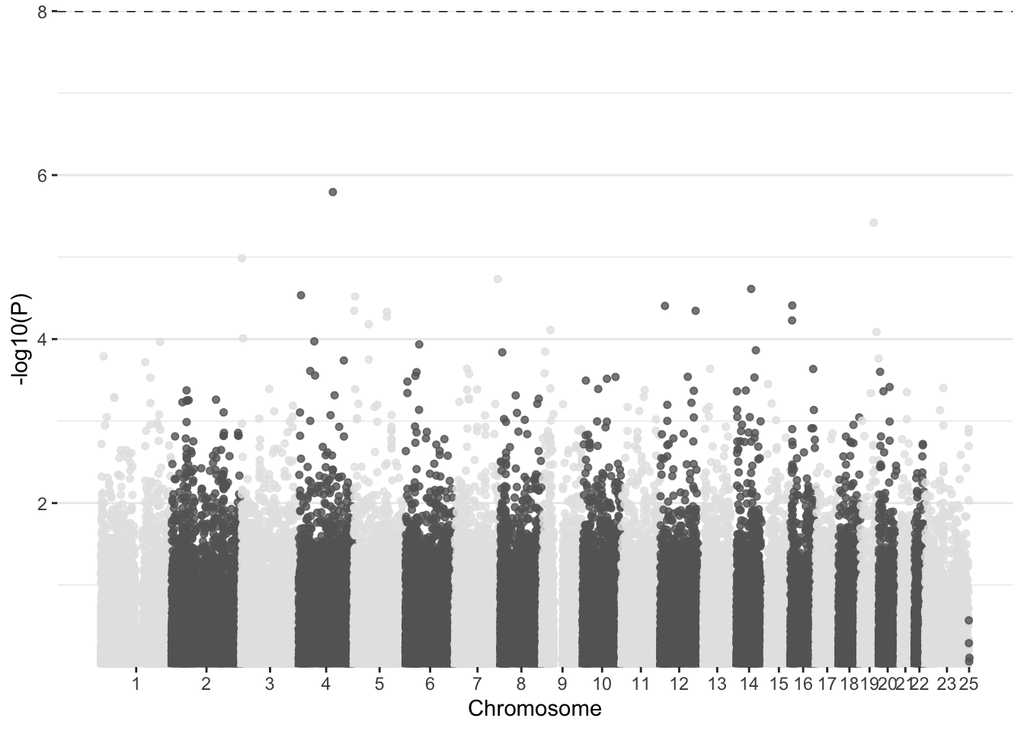

```r
# Extract the resulting − log10(P-values) of association for each SNP
pval.log10 <- -log10(p.value(res.adj))

# Create a Manhattan plot
library(tidyverse)
library(ggplot2)
library(ggrepel)
pvals <-
  data.frame(
    SNP = annotation$snp.name,
    CHR = annotation$chromosome,
    BP = annotation$position,
    P = p.value(res.adj)
  )
pvals <- subset(pvals,!is.na(CHR) & !is.na(P))

manhattanPlot(pvals, color = c("gray90", "gray40"))
```